# myHW

`r barplot(table(data$Age), main="Age Distribution", xlab="Age", ylab="Frequency")`

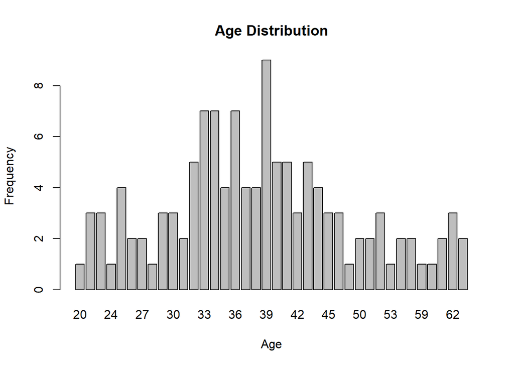

`r boxplot.stats(data$Age)$out`

`## Warning in Ops.factor(x[floor(d)], x[ceiling(d)]): '+' not meaningful for ## factors`

`## factor() ## 38 Levels: 20 22 23 24 25 26 27 28 29 30 31 32 33 34 35 36 37 38 39 40 ... 64`

# Convert the “Age” column back to numeric

`r data$Age <- as.numeric(as.character(data$Age)) outliers <- boxplot.stats(data$Age)$out range_of_age <- range(data$Age)`

# Print the results

`r print(outliers)`

`## [1] 61 64 62 61 62 62 64`

`r print(range_of_age)`

`## [1] 20 64`

[figure not shown]

[figure not shown]